# Homework 1: Insights on Poverty and Vaccines

October 7, 2022

# Part 1

This HW is based on Hans Rosling talks [New Insights on Poverty](https://www.ted.com/talks/hans_rosling_reveals_new_insights_on_poverty?language=en) and [The Best Stats You’ve Ever Seen](https://www.ted.com/talks/hans_rosling_shows_the_best_stats_you_ve_ever_seen).

1. Sri Lanka or Turkey
2. Poland or South Korea
3. Malaysia or Russia
4. Pakistan or Vietnam
5. Thailand or South Africa

Most people get them wrong. Why is this? In part it is due to our preconceived notion that the world is divided into two groups: the *Western world* versus the *third world*, characterized by “long life, small family” and “short life, large family” respectively. In this homework we will use data visualization to gain insights on this topic.

# Problem 1

The first step in our analysis is to download and organize the data. The necessary data to answer these question is available [here](https://raw.githubusercontent.com/datasciencelabs/2022/master/gapminder.csv).

## Problem 1.1

Read in the provided data using the `read_csv` function. Note that you can directly supply the link.

```r
library(tidyr)
library(dplyr)
```

```r
library(readr)
library(ggplot2)
theme_set(theme_bw()) ##optional

dat <- read_csv('https://raw.githubusercontent.com/datasciencelabs/2022/master/gapminder.csv')
```

## Problem 1.2

Write a function called `my_func` that takes a table as an argument and returns the first 5 column names. Print out the first 5 column names for the data you read in.

```r
my_func <- function(tab) {
  colnames(tab)[1:5]
}

my_func(dat)
```

```
## [1] "...1"             "year"             "country"          "infant_mortality"
## [5] "life_expectancy"
```

## Problem 1.3

Print out the first 6 rows. Notice that some of the column names don’t seem quite right, and the first column is extraneous. Fix the column names for this data, and remove the first column.

```r
head(dat)
```

```
## # A tibble: 6 × 10
##    ...1 year     country infan…¹ life_…² ferti…³ popul…⁴      gdp conti…⁵ region
##   <dbl> <chr>      <dbl>   <dbl>   <dbl>   <dbl>   <dbl>    <dbl> <chr>   <chr>
## 1     1 Albania     1960   115.     62.9    6.19  1.64e6 NA       Europe  South…
## 2     2 Algeria     1960   148.     47.5    7.65  1.11e7  1.38e10 Africa  North…
## 3     3 Angola      1960   208      36.0    7.32  5.27e6 NA       Africa  Middl…
## 4     4 Antigua…    1960    NA      63.0    4.43  5.47e4 NA       Americ… Carib…
## 5     5 Argenti…    1960    59.9    65.4    3.11  2.06e7  1.08e11 Americ… South…
## 6     6 Armenia     1960    NA      66.9    4.55  1.87e6 NA       Asia    Weste…
## # … with abbreviated variable names ¹infant_mortality, ²life_expectancy,
## #   ³fertility, ⁴population, ⁵continent
```

```r
dat <- dat %>% select(-1)
colnames(dat)[1:2] <- c('country','year')
```

# Problem 2

To examine if in fact there was a long-life-in-a-small-family and short-life-in-a-large-family dichotomy, we will visualize the average number of children per family (fertility) and the life expectancy for each country.

## Problem 2.1

Use `ggplot2` to create a plot of life expectancy versus fertility for 1962 for Africa, Asia, Europe, and the Americas. Use color to denote continent and point size to denote population size:

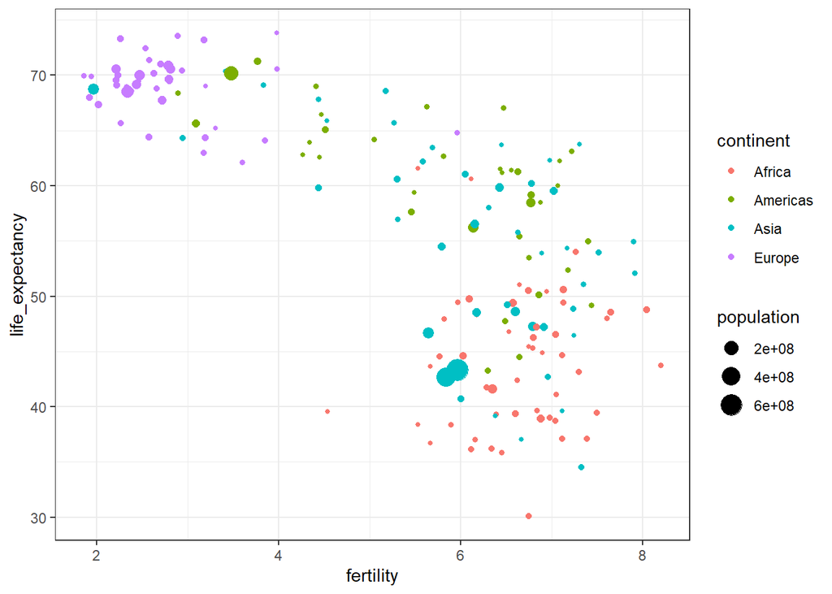

```r
p <- ggplot( filter(dat, year==1962 & continent != "Oceania"), aes(x=fertility, y=life_expectancy))
p + geom_point( aes( color=continent, size=population))
```

Do you see a dichotomy? Explain.

## Problem 2.2

Now we will annotate the plot to show different types of countries.

Learn about OECD and OPEC. Add a couple of columns to your consolidated tables containing a logical vector that tells if a country is OECD and OPEC respectively.

```r
oecd <- c('Australia','Austria','Belgium','Canada','Chile','Colombia','Costa Rica','Czech Republic',
          'Denmark','Estonia','Finland','France','Germany','Greece','Hungary','Iceland','Ireland',
          'Israel','Italy','Japan','Korea','Latvia','Lithuania','Luxembourg','Mexico','Netherlands',
          'New Zealand','Norway','Poland','Portugal','Slovak Republic','Slovenia','Spain','Sweden',
          'Switzerland','Turkey','United Kingdom','United States')

opec <- c('Iran','Iraq','Kuwait','Saudi Arabia','Venezuela','Libya','United Arab Emirates','Algeria','Nigeria',
          'Angola','Equatorial Guinea','Congo','Gabon')

dat <- mutate(dat, oecd = country %in% oecd, opec = country %in% opec)
```

### Problem 2.3

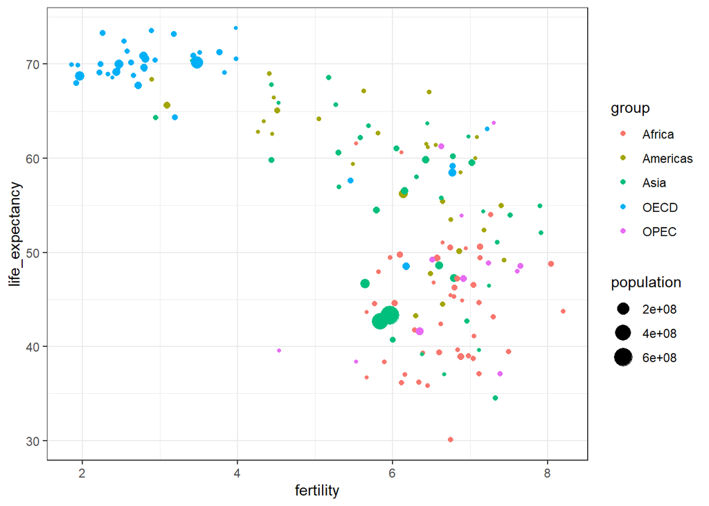

```r
group <- ifelse( dat$country%in%oecd , "OECD", dat$continent  )
group <- ifelse( dat$country%in%opec , "OPEC", group  )
group <- ifelse( group%in%c("Europe","Oceania"), NA, group)

##add group and avoid NAs
dat2 <- mutate(dat, group=group) %>%
  filter(!is.na(group) & !is.na(population) & !is.na(fertility) & !is.na(life_expectancy))

p <- ggplot( mutate(dat2, group = group) %>% filter(year==1962),
             aes(x=fertility, y=life_expectancy))
p + geom_point( aes( color=group, size=population))
```

How would you describe the dichotomy?

### Problem 2.4

Explore how this figure changes across time. Show us 4 figures that demonstrate how this figure changes through time.

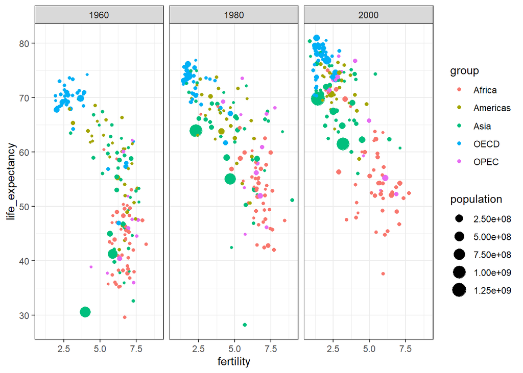

```r
years <-  c(1960, 1980, 2000, 2020)
p <- ggplot( mutate(dat2, group = group) %>% filter(year%in%years),
             aes(x=fertility, y=life_expectancy))
p + geom_point( aes( color=group, size=population)) + facet_wrap(~year)
```

Would you say that the same dichotomy exists today? Explain:

# Problem 3

Having time as a third dimension made it somewhat difficult to see specific country trends. Let’s now focus on specific countries.

## Problem 3.1

Let’s compare France and its former colony Tunisia. Make a plot of fertility versus year with color denoting the country. Do the same for life expectancy. How would you compare Tunisia’s improvement compared to France’s in the past 60 years? Hint: use `geom_line`.

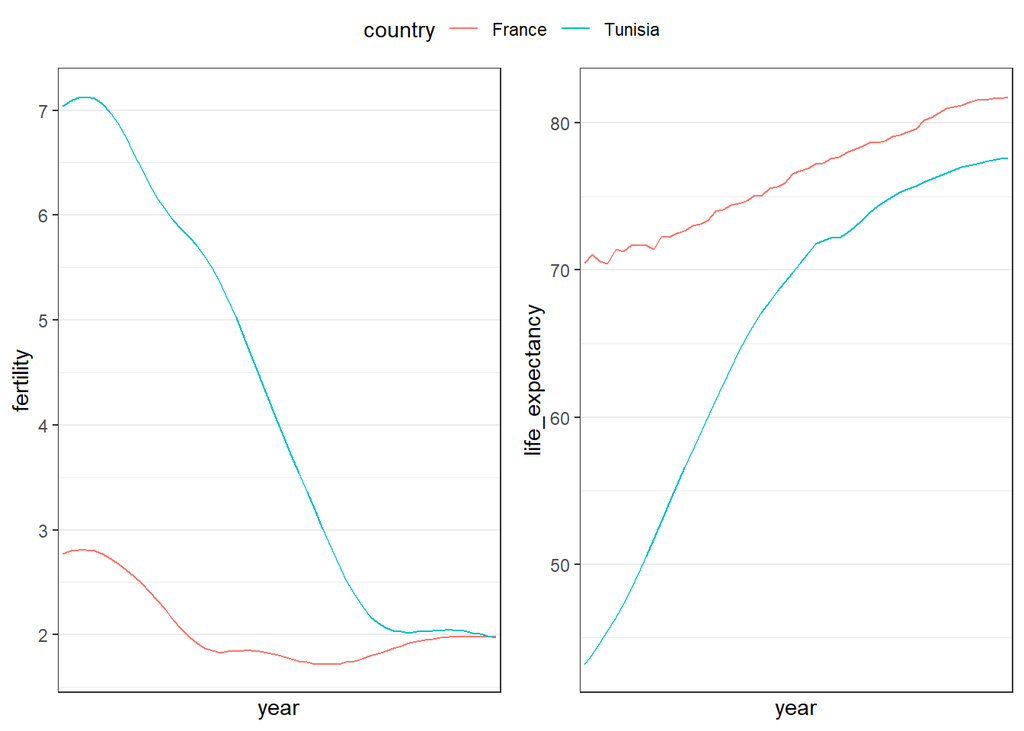

```r
countries <- c("Tunisia","France")
p1 <- ggplot(filter(dat2, country %in% countries & year > 1959 & year < 2022),
             aes(year,fertility,group=country,color=country)) + geom_line() + theme(legend.position="none") +
  scale_x_discrete(breaks=c(1960,1980,2000,2020))
p2 <- ggplot(filter(dat2, country %in% countries & year > 1959 & year < 2022),
             aes(year,life_expectancy,group=country,color=country)) + geom_line() + theme(legend.position="none") +
  scale_x_discrete(breaks=c(1960,1980,2000,2020))

library(ggpubr) ##this is optional

ggarrange(p1, p2, ncol = 2, common.legend=T)
```

## Problem 3.2

Do the same, but this time compare Vietnam to the OECD countries. Use one color for Vietnam, and another color for all the other OECD countries.

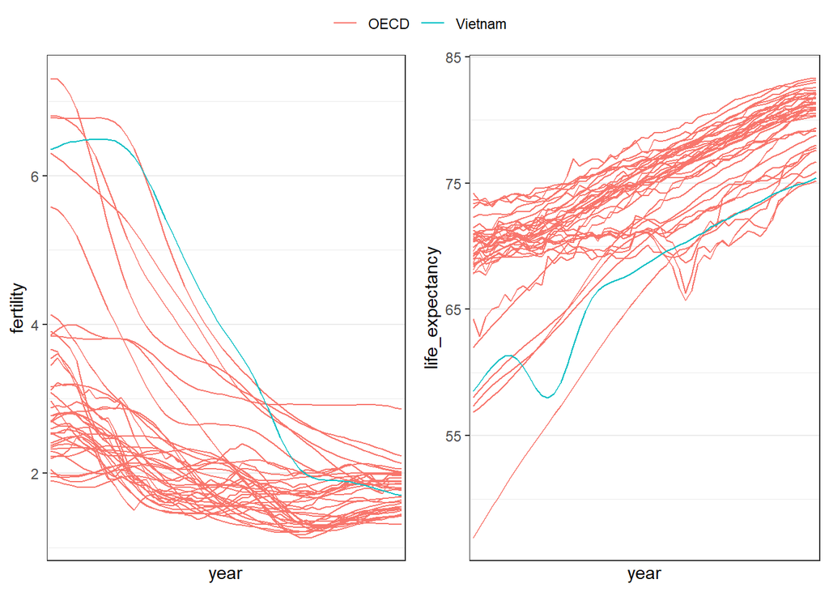

```r
countries <- c("Vietnam",oecd)
p1 <- ggplot( filter(dat2, country%in%countries & year > 1959 & year < 2022),
             aes(year,fertility,group=country,color=ifelse(oecd,'OECD','Vietnam'))) +
  geom_line() + theme(legend.position="none") + labs(color='') +
  scale_x_discrete(breaks=c(1960,1980,2000,2020))
p2 <- ggplot( filter(dat2, country%in%countries & year > 1959 & year < 2022),
             aes(year,life_expectancy,group=country,color=ifelse(oecd,'OECD','Vietnam'))) +
  geom_line() + theme(legend.position="none") + labs(color='') +
  scale_x_discrete(breaks=c(1960,1980,2000,2020))
ggarrange(p1, p2, ncol = 2, common.legend=T)
```

# Part 2

Vaccines have helped save millions of lives. In the 19th century, before herd immunization was achieved through vaccination programs, deaths from infectious diseases, like smallpox and polio, were common. However, today, despite all the scientific evidence for their importance, vaccination programs have become somewhat controversial.

The controversy started with a paper published in 1988 and lead by [Andrew Wakefield](https://en.wikipedia.org/wiki/Andrew_Wakefield) claiming there was a link between the administration of the measles, mumps and rubella (MMR) vaccine, and the appearance of autism and bowel disease.

Despite much science contradicting this finding, sensationalists media reports and fear mongering from conspiracy theorists, led parts of the public to believe that vaccines were harmful. Some parents stopped vaccinating their children. This dangerous practice can be potentially disastrous given that the Center for Disease Control (CDC) estimates that vaccinations will prevent more than 21 million hospitalizations and 732,000 deaths among children born in the last 20 years (see [Benefits from Immunization during the Vaccines for Children Program Era — United States, 1994-2013, MMWR](https://www.cdc.gov/mmwr/preview/mmwrhtml/mm6316a4.htm)).

Effective communication of data is a strong antidote to misinformation and fear mongering. In this homework you are going to prepare a report to have ready in case you need to help a family member, friend or acquaintance that is not aware of the positive impact vaccines have had for public health.

The data used for these plots were collected, organized and distributed by the [Tycho Project](http://www.tycho.pitt.edu/). They include weekly reported counts data for seven diseases from 1928 to 2011, from all fifty states. We include the yearly totals in the `dslabs` package:

```r
library(dslabs)
data(us_contagious_diseases)
```

1. Use the `us_contagious_disease` and `dplyr` tools to create an object called `dat` that stores only the Measles data, includes a per 100,000 people rate, and removes Alaska and Hawaii since they only became states in the late 50s. Note that there is a `weeks_reporting` column. Take that into account when computing the rate.

```r
the_disease <- "Measles"
dat <- us_contagious_diseases %>%
    filter(!state %in% c("Hawaii","Alaska"),
           disease == the_disease) %>%
    mutate(rate = (count / weeks_reporting) * 52 / (population / 100000)) %>%
    mutate(state = reorder(state, rate))
```

2. Plot the Measles disease rates per year for California. Find out when the Measles vaccine was introduced and add a vertical line to the plot to show this year.

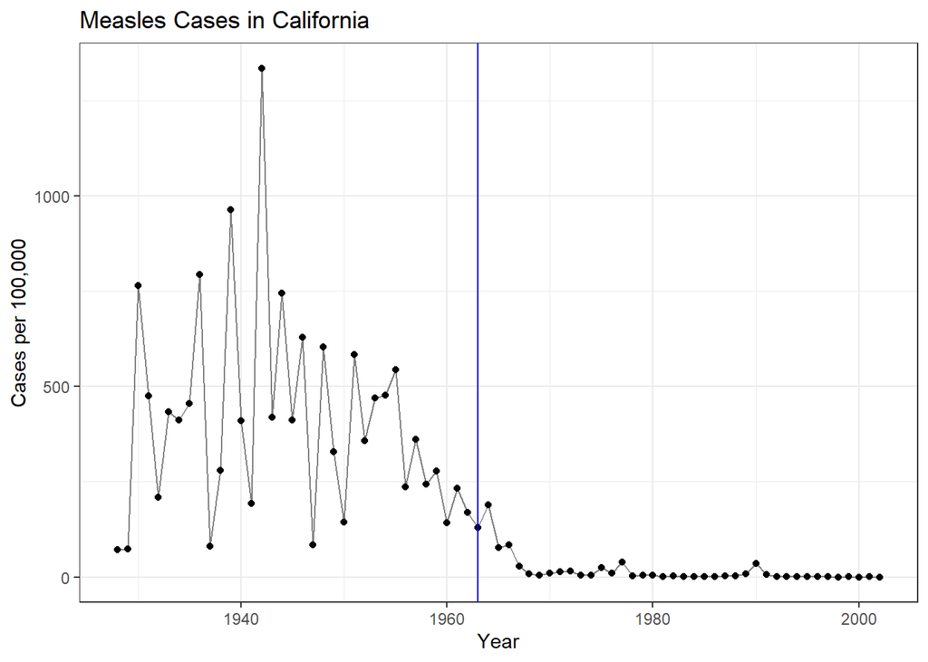

```r
dat %>%
    filter(state == "California", !is.na(rate)) %>%
    ggplot(aes(x = year, y = rate)) +
    geom_line(alpha = 1/2) +
    geom_point() +
    ylab("Cases per 100,000") +
    xlab("Year") +
    ggtitle("Measles Cases in California") +
    geom_vline(xintercept = 1963, col = "blue")
```

3. Note these rates start off as counts. For larger counts we can expect more variability. There are statistical explanations for this which we don’t discuss here. But transforming the data might help stabilize the variability such that it is closer across levels. For 1950, 1960, and 1970, plot the histogram of the data across states with and without the square root transformation. Which seems to have more similar variability across years? Make sure to pick binwidths that result in informative plots.

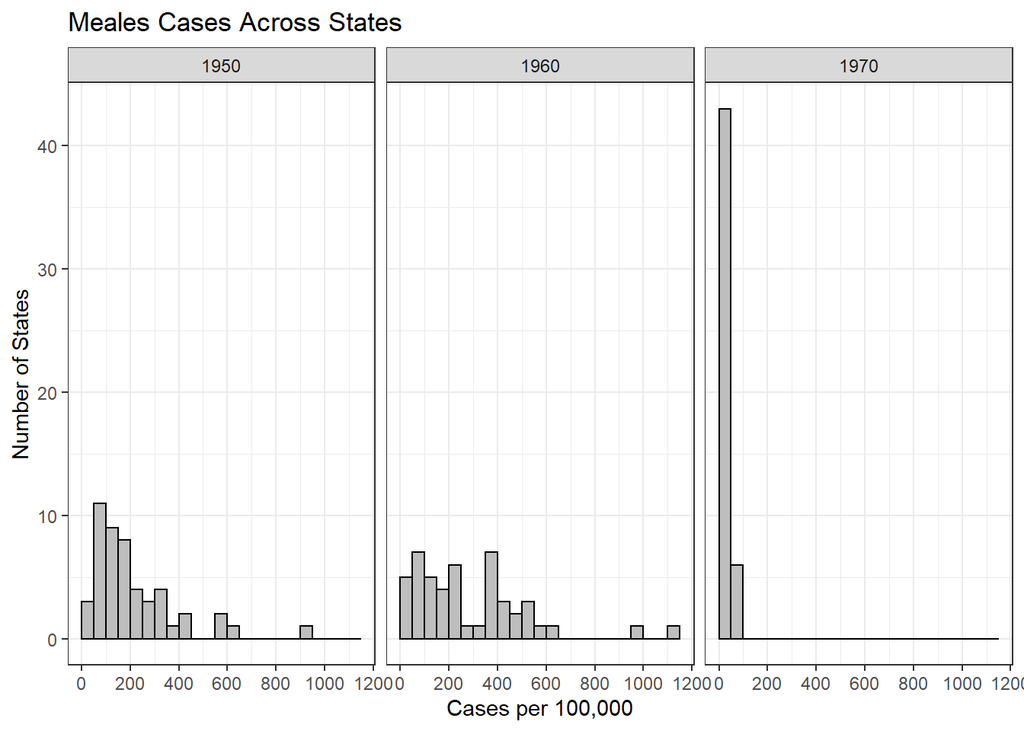

```r
dat %>%
    filter(year %in% c(1950,1960,1970), !is.na(rate)) %>%
    ggplot(aes(x = rate)) +
    geom_histogram(color = "black", fill = "gray", boundary = 0, binwidth = 50) +
    ylab("Number of States") +
    xlab("Cases per 100,000") +
    facet_grid(. ~ year) +
    scale_x_continuous(breaks = seq(0, 1e5, 2e2)) +
    ggtitle("Meales Cases Across States")
```

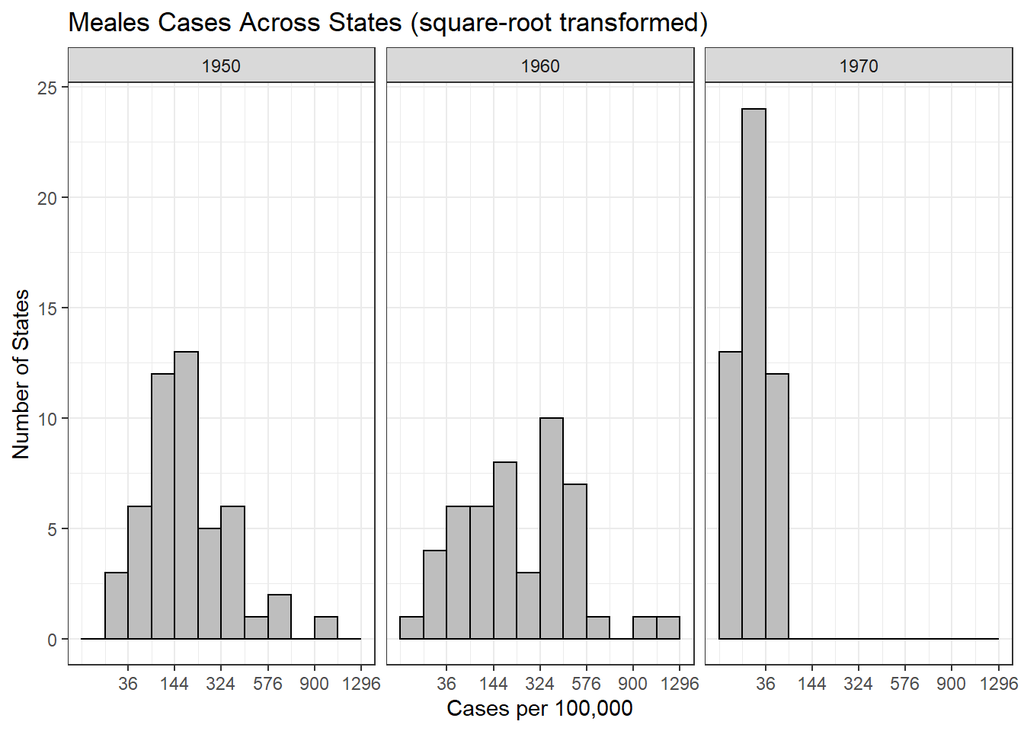

```r
dat %>%
    filter(year %in% c(1950, 1960, 1970), !is.na(rate)) %>%
    ggplot(aes(x = rate)) +
    geom_histogram(color = "black", fill = "gray", boundary = 0, binwidth = 3) +
    ylab("Number of States") +
    xlab("Cases per 100,000") +
    facet_grid(. ~ year) +
    scale_x_sqrt(breaks = seq(0, 50, 6)^2) +
    ggtitle("Meales Cases Across States (square-root transformed)")
```

4. Plot the Measles disease rates per year for California. Use the the square root transformation. Make sure that the numbers
   $$0,4,16,36, \dots, 100$$
   appear on the y-axis. Find out when the Measles vaccine was introduced and add a vertical line to the plot to show this year:

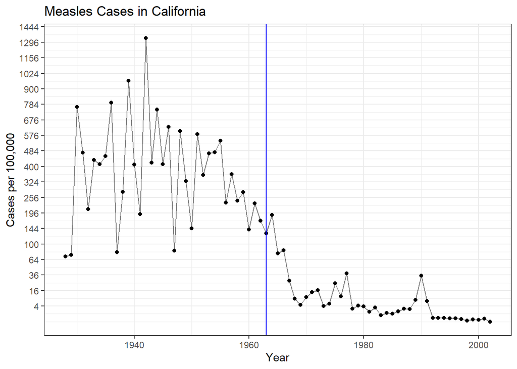

```r
dat %>%
    filter(state == "California", !is.na(rate)) %>%
    ggplot(aes(x = year, y = rate)) +
    geom_line(alpha = 1/2) +
    geom_point() +
    scale_y_sqrt("Cases per 100,000", breaks = seq(0, 100, 2)^2) +
    xlab("Year") +
    ggtitle("Measles Cases in California") +
    geom_vline(xintercept = 1963, col = "blue")
```

5. Now, this is just California. Does the pattern hold for other states? Use boxplots, with year on the x-axis and rates on the y-axis, to get an idea of the distribution of rates for each year, and see if the pattern holds across states.

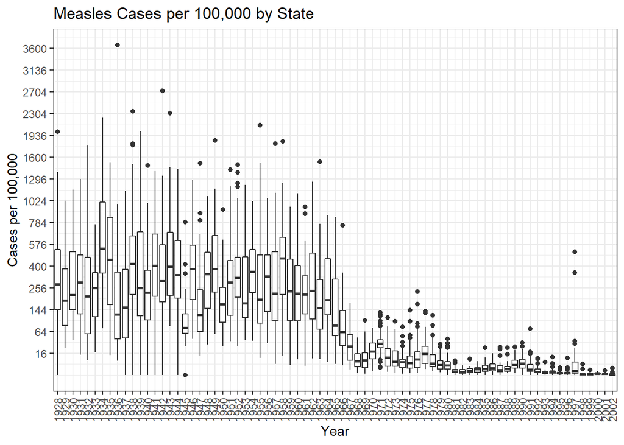

```r
dat %>%
    filter(!is.na(rate)) %>%
    ggplot(aes(x = factor(year), y = rate)) +
    geom_boxplot() +
    xlab("Year") +
    scale_y_sqrt("Cases per 100,000", breaks = seq(0, 100, 4)^2) +
    theme(axis.text.x = element_text(angle = 90, hjust = 1, vjust = 1/2)) +
    ggtitle("Measles Cases per 100,000 by State")
```

6. One problem with the boxplot is that it does not let us see state-specific trends. Make a plot showing the trends for all states, using `geom_line` to display each state’s trend in gray. Add the US average to the plot, also with `geom_line`, in black. Hint: Note there are missing values in the data.

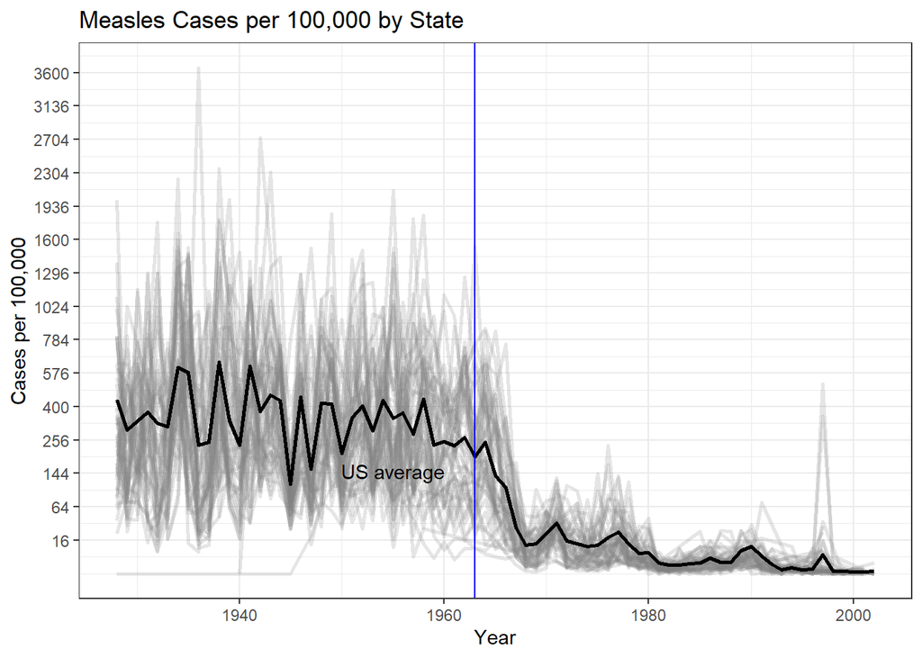

```r
avg <- dat %>%
    filter(weeks_reporting > 0) %>%
    group_by(year) %>%
    summarize(us_rate = sum(count / weeks_reporting) * 52 / sum(population / 100000))

dat %>%
    filter(!is.na(rate)) %>%
    ggplot() +
    geom_line(aes(x = year, y = rate, group = state), color = "grey50",
              show.legend = FALSE, alpha = 0.2, size = 1) +
    geom_line(data = avg, mapping = aes(x = year, y = us_rate),
              size = 1, color = "black") +
    xlab("Year") +
    scale_y_sqrt("Cases per 100,000", breaks = seq(0, 100, 4)^2) +
    ggtitle("Measles Cases per 100,000 by State") +
    geom_vline(xintercept=1963, col = "blue") +
    annotate(geom="text", x=1955, y=150, label="US average", color="black")
```

7. One problem with the plot above is that we can’t distinguish states from each other. There are just too many. We have three variables to show: year, state, and rate. If we use the two dimensions to show year and state, then we need something other than vertical or horizontal position to show the rates. Try using color. Hint: Use the the geometry `geom_tile` to tile the plot with colors representing disease rates.

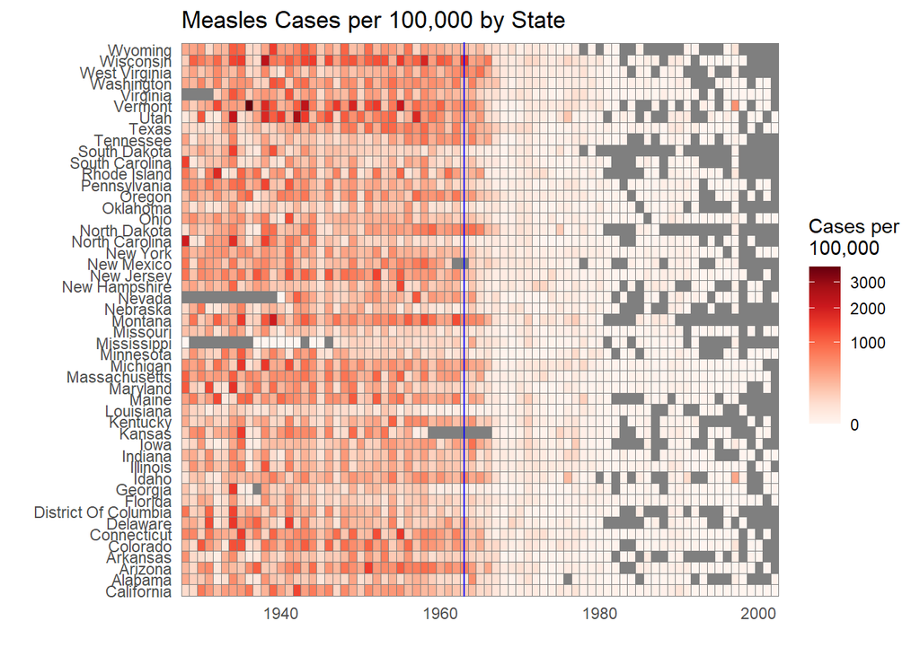

```r
library(RColorBrewer)
dat %>%
    ggplot(aes(x = year, y = state,  fill = rate)) +
    geom_tile(color = "grey50") +
    scale_x_continuous(expand = c(0,0)) +
    scale_fill_gradientn("Cases per\n100,000",
                         colors = brewer.pal(9, "Reds"),
                         trans = "sqrt") +
    geom_vline(xintercept = 1963, col = "blue") +
    theme_minimal() +
    theme(panel.grid = element_blank()) +
    ggtitle("Measles Cases per 100,000 by State") +
    ylab("") + xlab("")
```